# Sentiment Analysis Blog

# Sentiment Analysis in Data Science: Unlocking Insights from Text Data

### Introduction

In today’s data-driven world, businesses, governments, and individuals generate a massive amount of text data every day. From tweets to reviews, forums to customer feedback, all of this unstructured data holds valuable insights. One powerful technique used to extract meaning from this data is **sentiment analysis**—a subfield of Natural Language Processing (NLP). Sentiment analysis allows us to classify text data as positive, negative, or neutral, providing an understanding of people’s emotions, opinions, and attitudes.

But why is this important? Think of the last time you read a product review or checked social media for feedback about a brand. The ability to automatically classify and analyze these opinions can significantly enhance customer service, marketing strategies, and even public policy decisions. In this blog post, we will explore how sentiment analysis works, dive into different techniques and tools, and examine its real-world applications.

### What is Sentiment Analysis?

At its core, sentiment analysis is the task of determining the emotional tone behind a series of words. It’s widely used to understand public opinion, customer satisfaction, and the emotional tone of social media posts, reviews, and more.

Sentiment analysis is part of a broader category known as **opinion mining**. It deals with extracting subjective information from the text. The goal is to determine whether a piece of text expresses a positive, negative, or neutral sentiment.

#### Types of Sentiment

- **Positive**: The text expresses favorable opinions, emotions, or attitudes (e.g., “I love this product!”).
- **Negative**: The text conveys dissatisfaction, criticism, or negative emotions (e.g., “This is awful!”).
- **Neutral**: The text does not convey a strong sentiment (e.g., “The product was delivered on time.”).

### How Does Sentiment Analysis Work?

Sentiment analysis typically follows a series of steps:

#### 1. Data Collection

To perform sentiment analysis, you need a dataset. This might be a collection of tweets, product reviews, or survey responses. The key is to ensure that the data is representative of the target population or sentiment you’re trying to analyze.

#### 2. Data Preprocessing

Once the data is collected, it often requires preprocessing. This may include:

- **Tokenization**: Breaking the text into words or phrases.
- **Removing stopwords**: Common words like “the,” “a,” or “and” that don’t contribute to sentiment.
- **Lowercasing**: Standardizing text to lowercase to avoid case mismatches.
- **Stemming or Lemmatization**: Reducing words to their root form (e.g., “running” becomes “run”).

#### 3. Model Selection

There are two main approaches for sentiment analysis:

- **Rule-based methods**: These rely on predefined lexicons (lists of words associated with sentiment values) and rules to classify text.
- **Machine learning-based methods**: These involve training a model on labeled data to predict sentiment.

### Sentiment Analysis Techniques and Tools

#### Lexicon-based Approach

A common lexicon used for sentiment analysis is **VADER** (Valence Aware Dictionary and sEntiment Reasoner), which is a rule-based approach. It works by scoring words based on their emotional intensity and combining these scores to classify the sentiment of the whole sentence.

#### Machine Learning-based Approach

In the **supervised learning** method, you train a classifier (such as Naive Bayes or SVM) on a labeled dataset to learn to classify text into sentiment categories. This method can handle more nuanced sentiment and is often more accurate than lexicon-based approaches.

#### Deep Learning-based Approach

For more complex tasks, **deep learning** methods like **Long Short-Term Memory (LSTM)** networks can be used. These models are capable of capturing intricate patterns in text, especially when it comes to things like sarcasm or context-based meaning.

### Case Study: Implementing Sentiment Analysis with Python

Let’s take a look at a sentence simple sentiment analysis task using **Python**.

```python
from textblob import TextBlob

# Sample text
text = "I love the quality of this product. It's fantastic!"

# Create a TextBlob object
blob = TextBlob(text)

# Get the sentiment polarity
sentiment = blob.sentiment.polarity

# Print the sentiment
if sentiment > 0:
    print("Positive Sentiment")
elif sentiment < 0:
    print("Negative Sentiment")
else:
    print("Neutral Sentiment")
```

### Case Study 2: Implement Sentiment Analysis in a paragraph with Python

Let’s take a look at a simple paragraph sentiment analysis task using **Python**.

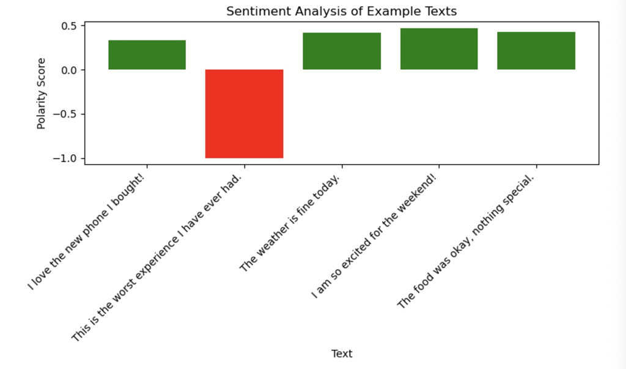

```python
import matplotlib.pyplot as plt
import os
from textblob import TextBlob

current_dir = os.getcwd()
output_dir = os.path.join(current_dir, "images")
if not os.path.exists(output_dir):
    os.makedirs(output_dir)

# Example texts for sentiment analysis
texts = [
    "I love the new phone I bought!",
    "This is the worst experience I have ever had.",
    "The weather is fine today.",
    "I am so excited for the weekend!",
    "The food was okay, nothing special."
]

# Analyze sentiment and store polarity
polarity_scores = []
for text in texts:
    blob = TextBlob(text)
    polarity_scores.append(blob.sentiment.polarity)

# Print the polarity scores for each text
for text, polarity in zip(texts, polarity_scores):
    print(f"Text: {text}\nPolarity: {polarity}\n")

# Step 3: Visualizing Sentiment Polarity
# Plotting the sentiment scores using seaborn
plt.figure(figsize=(8, 5))
plt.bar(texts, polarity_scores, color=['green' if score > 0 else 'red' for score in polarity_scores])
plt.title("Sentiment Analysis of Example Texts")
plt.xlabel("Text")
plt.ylabel("Polarity Score")
plt.xticks(rotation=45, ha="right")
plt.tight_layout()

plot_dir = os.path.join(output_dir, "sentiment_plot.png")
plt.savefig(plot_dir)
plt.close()
```

The bar plot clearly shows that the texts in the paragraph are mostly positive, except for the second one. The result is very convincing because the second text message include very negative polarity word “worst”.

### Real-World Applications of Sentiment Analysis

#### Social Media Monitoring

Businesses often use sentiment analysis to track brand perception on platforms like Twitter and Instagram. By analyzing the tone of posts, they can quickly respond to customer complaints or gauge public opinion about a product launch.

#### Customer Feedback Analysis

Customer feedback, whether collected through surveys or product reviews, can be analyzed to uncover common issues or opportunities for improvement. This is particularly useful in industries like retail, hospitality, and tech.

#### Political and Social Trend Analysis

Sentiment analysis is also used in political campaigns to monitor public sentiment around candidates or issues. For example, during elections, campaigns may analyze social media and news articles to gauge voter sentiment.

### Challenges in Sentiment Analysis

Despite its usefulness, sentiment analysis faces several challenges:

#### Sarcasm and Irony: Detecting sarcasm remains a major challenge, as a sentence like “This is the worst product ever!” could be positive or negative depending on the context.

#### Multilingual Sentiment: Sentiment analysis models trained on English may not perform well in other languages. Multilingual sentiment analysis requires custom solutions or additional training data.

#### Bias in Data: If the training data contains biased language, the model might inherit those biases. It’s important to carefully curate training datasets to ensure fairness.

### The Future of Sentiment Analysis

The future of sentiment analysis lies in multi-modal sentiment analysis, where text, audio, and even visual content are analyzed together to understand sentiment more comprehensively. Deep learning techniques, especially transformers like BERT and GPT, are also pushing the boundaries of what sentiment analysis can achieve.

### Conclusion

Sentiment analysis plays a critical role in extracting actionable insights from large volumes of text data. By leveraging NLP and machine learning techniques, businesses and organizations can understand public opinion, track brand perception, and improve customer satisfaction. While challenges remain, the field continues to evolve, with new methods and applications emerging every year. If you’re interested in exploring sentiment analysis further, there’s never been a better time to start experimenting with the powerful tools available today.